# Workplace-Intervention_03-Findings

Author

SSK

Published

September 10, 2024

# Descriptives

**Condition**

| Condition | Freq |
| --- | --- |
| Control | 103 |
| Treatment | 105 |

**School / Division**

| School / Division | Freq |
| --- | --- |
| Athletics | 2 |
| Education | 4 |
| Goldman | 5 |
| Haas | 39 |
| Law | 39 |
| Social Welfare | 5 |
| Student Affairs | 82 |
| UDAR | 32 |

**Academic / Staff**

| Academic / Staff | Freq |
| --- | --- |
| Academic | 7 |
| Staff | 199 |

**Manager**

| Manager | Freq |
| --- | --- |
| No | 121 |
| Yes | 86 |

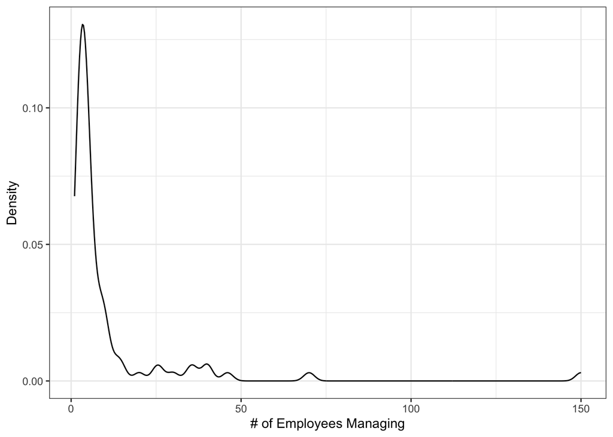

**Gender**

| Gender | Freq |
| --- | --- |
| Female | 136 |
| Genderqueer or Nonbinary Gender | 17 |
| Male | 54 |
| Trans Male / Trans Man | 1 |

**Race**

| Race | Freq |
| --- | --- |
| African American / Black | 7 |
| American Indian / Alaskan Native | 2 |
| Chinese | 12 |
| Filipino | 6 |
| Hispanic / Latino | 26 |
| Japanese | 1 |
| Korean | 3 |
| Middle Eastern / Southwest Asian / North African (SWANA) | 3 |
| Other Asian | 3 |
| Pacific Islander | 1 |
| South Asian | 1 |
| Two or more races | 20 |
| White | 122 |

**SES**

| Income | Freq |
| --- | --- |
| $100,001 - $150,000 | 52 |
| $15,000 - $30,000 | 2 |
| $30,001 - $50,000 | 6 |
| $50,001 - $75,000 | 30 |
| $75,001 - $100,000 | 32 |
| greater than $150,000 | 85 |

|  | vars | n | mean | sd | median | trimmed | mad | min | max | range | skew | kurtosis | se |
| --- | --- | --- | --- | --- | --- | --- | --- | --- | --- | --- | --- | --- | --- |
| X1 | 1 | 208 | 6.274038 | 1.620192 | 6 | 6.309524 | 1.4826 | 1 | 10 | 9 | -0.2622573 | -0.0171127 | 0.1123401 |

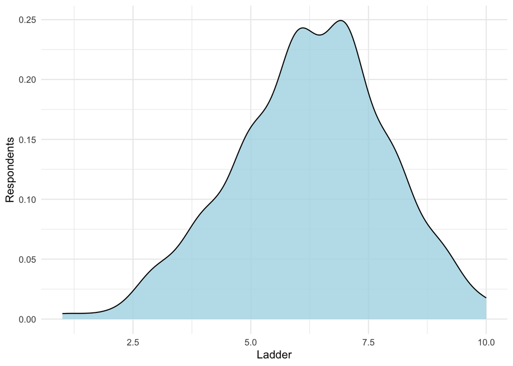

# High-Level Findings

**Confirmatory**

**Exploratory**

- Treatment had a marginal effect on **perspective-taking** for manager scenario

**Session 2**

# Key

| Symbol | Sig. Level | *p* |
| --- | --- | --- |
| 🟢 | Significant | < 0.05 |
| ️️🟡 | Marginal / Trending | 0.05 - 0.09 |
| 🔴 | Non-Significant | > 0.10 |

# Session 1

# Confirmatory

## 1. Relationship-prioritization 🟢

*How likely are you to prioritize establishing a positive relationship with every single co-worker in your workplace?*

```
Call:
lm(formula = manipTreat1 ~ Condition + wave, data = data)

Residuals:
    Min      1Q  Median      3Q     Max
-4.2672 -1.1105  0.3787  1.3787  2.3787

Coefficients:
                   Estimate Std. Error t value Pr(>|t|)
(Intercept)          4.1843     0.4671   8.958 4.87e-15 ***
ConditionTreatment   0.6459     0.3064   2.108   0.0371 *
wave                 0.4370     0.3120   1.401   0.1639
---
Signif. codes:  0 '***' 0.001 '**' 0.01 '*' 0.05 '.' 0.1 ' ' 1

Residual standard error: 1.688 on 121 degrees of freedom
  (91 observations deleted due to missingness)
Multiple R-squared:  0.05737,   Adjusted R-squared:  0.04179
F-statistic: 3.682 on 2 and 121 DF,  p-value: 0.02804
```

```
No summary function supplied, defaulting to `mean_se()`
```

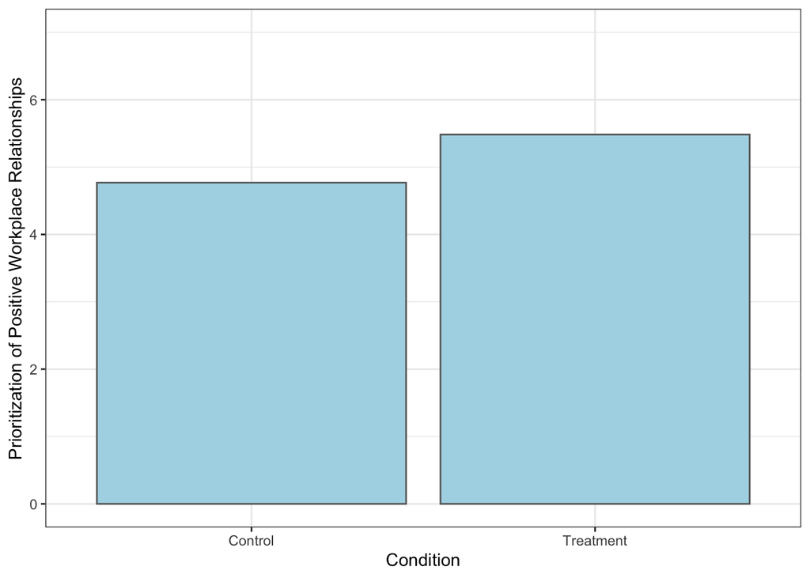

## 2. Multiple-selves / Complexity Beliefs 🟢

*How much do you agree with the following statement?: Everyone in the workplace is complex inside and is capable of tapping into different parts of themself.*

```
Call:
lm(formula = manipTreat2_recode ~ Condition + wave, data = data)

Residuals:
    Min      1Q  Median      3Q     Max
-1.5192 -0.5192  0.2041  0.4808  0.5149

Coefficients:
                   Estimate Std. Error t value Pr(>|t|)
(Intercept)         4.55342    0.15982  28.491  < 2e-16 ***
ConditionTreatment  0.27662    0.10485   2.638  0.00943 **
wave               -0.03416    0.10674  -0.320  0.74950
---
Signif. codes:  0 '***' 0.001 '**' 0.01 '*' 0.05 '.' 0.1 ' ' 1

Residual standard error: 0.5775 on 121 degrees of freedom
  (91 observations deleted due to missingness)
Multiple R-squared:  0.05441,   Adjusted R-squared:  0.03878
F-statistic: 3.481 on 2 and 121 DF,  p-value: 0.03388
```

```
No summary function supplied, defaulting to `mean_se()`
```

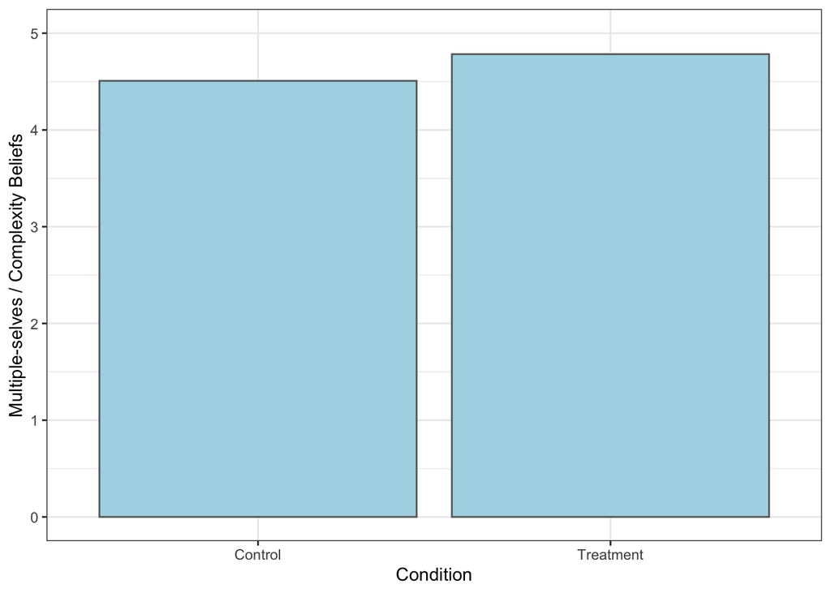

## 3. Perspective-taking

$\alpha = 0.62$

**Per preregistration, will therefore look at items individually**

*Over the next 2 weeks while at work…*

**a. 🔴**

*if I’m sure I’m right about something, I won’t waste much time listening to other people’s arguments.*

```
Call:
lm(formula = IRI_PT_1 ~ Condition + wave, data = data)

Residuals:
    Min      1Q  Median      3Q     Max
-1.3423 -0.3423 -0.1814  0.6577  2.9508

Coefficients:
                   Estimate Std. Error t value Pr(>|t|)
(Intercept)          2.4745     0.2555   9.683   <2e-16 ***
ConditionTreatment  -0.1609     0.1671  -0.963    0.337
wave                -0.1322     0.1699  -0.778    0.438
---
Signif. codes:  0 '***' 0.001 '**' 0.01 '*' 0.05 '.' 0.1 ' ' 1

Residual standard error: 0.9175 on 120 degrees of freedom
  (92 observations deleted due to missingness)
Multiple R-squared:  0.01448,   Adjusted R-squared:  -0.001942
F-statistic: 0.8818 on 2 and 120 DF,  p-value: 0.4167
```

**b. 🔴**

*I will sometimes try to understand my coworkers better by imagining howthings look from their perspective.*

```
Call:
lm(formula = IRI_PT_2 ~ Condition + wave, data = data)

Residuals:
    Min      1Q  Median      3Q     Max
-3.4341 -0.3567 -0.3370  0.5856  0.6630

Coefficients:
                   Estimate Std. Error t value Pr(>|t|)
(Intercept)         4.31733    0.19167  22.525   <2e-16 ***
ConditionTreatment  0.07741    0.12532   0.618    0.538
wave                0.01966    0.12747   0.154    0.878
---
Signif. codes:  0 '***' 0.001 '**' 0.01 '*' 0.05 '.' 0.1 ' ' 1

Residual standard error: 0.6882 on 120 degrees of freedom
  (92 observations deleted due to missingness)
Multiple R-squared:  0.00364,   Adjusted R-squared:  -0.01297
F-statistic: 0.2192 on 2 and 120 DF,  p-value: 0.8035
```

**c. 🟡**

*I will believe that there are two sides to every question and try to look at them both.*

```
Call:
lm(formula = IRI_PT_3 ~ Condition + wave, data = data)

Residuals:
     Min       1Q   Median       3Q      Max
-2.39383 -0.25719  0.04697  0.74281  1.04697

Coefficients:
                   Estimate Std. Error t value Pr(>|t|)
(Intercept)          3.8164     0.2469  15.454   <2e-16 ***
ConditionTreatment   0.3042     0.1615   1.884    0.062 .
wave                 0.1366     0.1642   0.832    0.407
---
Signif. codes:  0 '***' 0.001 '**' 0.01 '*' 0.05 '.' 0.1 ' ' 1

Residual standard error: 0.8866 on 120 degrees of freedom
  (92 observations deleted due to missingness)
Multiple R-squared:  0.03801,   Adjusted R-squared:  0.02198
F-statistic: 2.371 on 2 and 120 DF,  p-value: 0.09775
```

```
No summary function supplied, defaulting to `mean_se()`
```

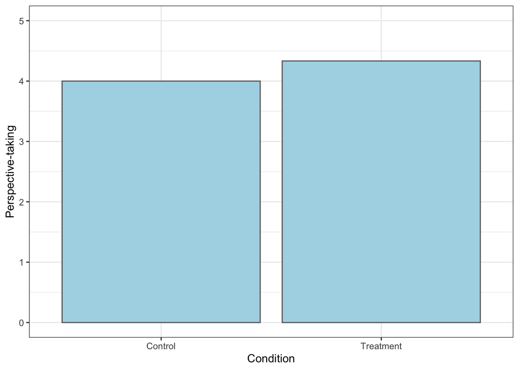

**d. 🟢**

*I will try to look at everybody’s side of a disagreement before I make a decision.*

```
Call:
lm(formula = IRI_PT_4 ~ Condition + wave, data = data)

Residuals:
    Min      1Q  Median      3Q     Max
-2.3983 -0.3983 -0.1082  0.6017  0.8918

Coefficients:
                   Estimate Std. Error t value Pr(>|t|)
(Intercept)         4.01887    0.22230  18.079   <2e-16 ***
ConditionTreatment  0.29005    0.14584   1.989    0.049 *
wave                0.08935    0.14847   0.602    0.548
---
Signif. codes:  0 '***' 0.001 '**' 0.01 '*' 0.05 '.' 0.1 ' ' 1

Residual standard error: 0.8032 on 121 degrees of freedom
  (91 observations deleted due to missingness)
Multiple R-squared:  0.0377,    Adjusted R-squared:  0.0218
F-statistic:  2.37 on 2 and 121 DF,  p-value: 0.09778
```

```
No summary function supplied, defaulting to `mean_se()`
```

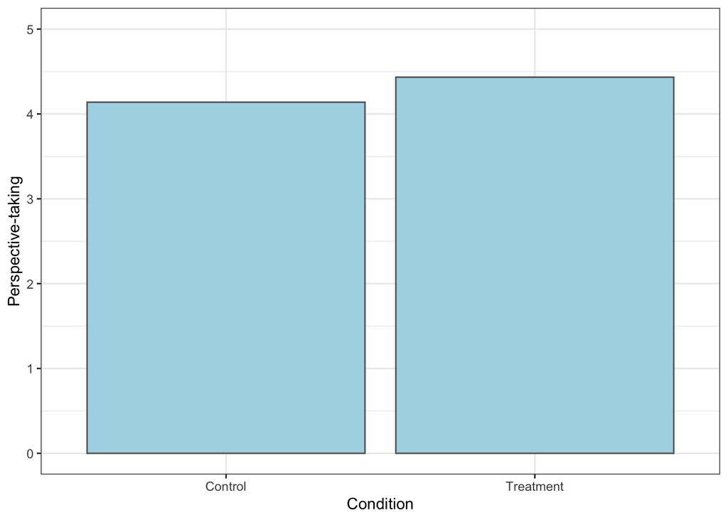

# Exploratory

## Burnout 🟡 w/ URM as covariate

```
Call:
lm(formula = burnout ~ Condition * URM + wave, data = data)

Residuals:
    Min      1Q  Median      3Q     Max
-3.1653 -1.1564  0.0632  1.1720  3.8436

Coefficients:
                          Estimate Std. Error t value Pr(>|t|)
(Intercept)                 3.2754     0.5368   6.102 2.67e-08 ***
ConditionTreatment          0.2196     0.3825   0.574   0.5672
URMYes                      0.2286     0.5518   0.414   0.6797
wave                        0.3307     0.3533   0.936   0.3518
ConditionTreatment:URMYes  -1.6081     0.9104  -1.766   0.0808 .
---
Signif. codes:  0 '***' 0.001 '**' 0.01 '*' 0.05 '.' 0.1 ' ' 1

Residual standard error: 1.655 on 89 degrees of freedom
  (121 observations deleted due to missingness)
Multiple R-squared:  0.047, Adjusted R-squared:  0.004171
F-statistic: 1.097 on 4 and 89 DF,  p-value: 0.3629
```

```
No summary function supplied, defaulting to `mean_se()`
No summary function supplied, defaulting to `mean_se()`
```

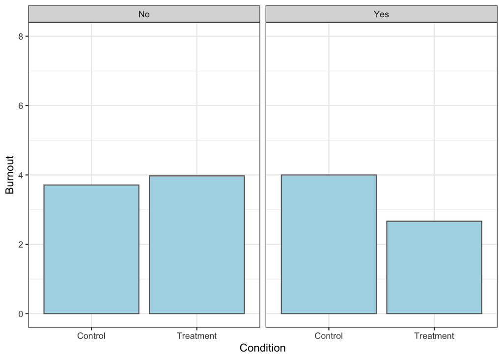

## Scenario 1 🔴

*You just started a new role as a manager. You regularly try to meet with your new employees both as a team and one-on-one to get to know them and to give them the opportunity to get to know you. In general, you have built a good rapport with many of them and they seem to like your leadership style. However, after a few weeks, you notice that one of your employees has seemed to do the bare minimum with some work duties and doesn’t seem mentally present in meetings. From what you have heard, this employee tended to go above and beyond in their work before you started your new role.*

## Scenario 2

*You just started reporting to a new manager. After a few weeks, you notice that the new manager has built rapport with some of your colleagues but hasn’t made much effort to get to know you. The new manager has several impromptu meetings per week and seems to forget to loop you in. Although you have been asked to pick up extra work, the manager doesn’t seem to acknowledge your effort or thank you for doing additional tasks.*

### Perspective-taking 🟡

```
Call:
lm(formula = IRI_PT1_2 ~ Condition + wave + manager, data = data)

Residuals:
    Min      1Q  Median      3Q     Max
-2.5312 -0.5072  0.1449  0.4487  1.5369

Coefficients:
                   Estimate Std. Error t value Pr(>|t|)
(Intercept)         3.63943    0.29929  12.160   <2e-16 ***
ConditionTreatment  0.32387    0.17980   1.801   0.0744 .
wave               -0.08817    0.18613  -0.474   0.6366
managerYes          0.06808    0.18361   0.371   0.7115
---
Signif. codes:  0 '***' 0.001 '**' 0.01 '*' 0.05 '.' 0.1 ' ' 1

Residual standard error: 0.9531 on 111 degrees of freedom
  (100 observations deleted due to missingness)
Multiple R-squared:  0.03001,   Adjusted R-squared:  0.003794
F-statistic: 1.145 on 3 and 111 DF,  p-value: 0.3343
```

```
No summary function supplied, defaulting to `mean_se()`
```

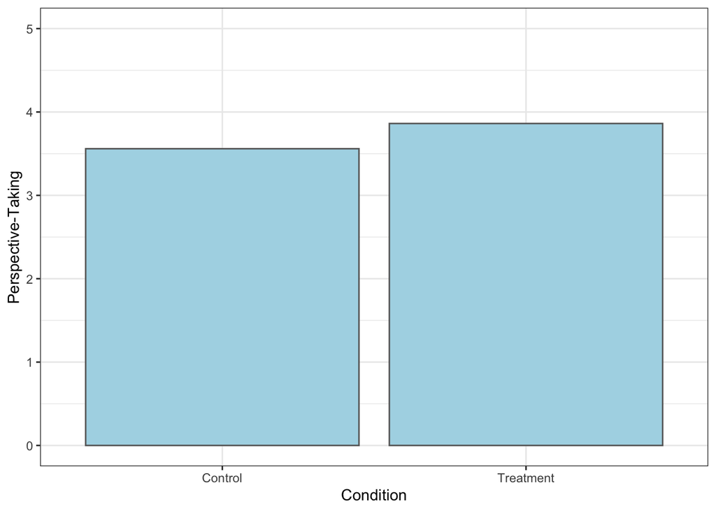

# Session 2

**Condition**

| Condition | Freq |
| --- | --- |
| Control | 30 |
| Treatment | 38 |

**School / Division**

| School / Division | Freq |
| --- | --- |
| Education | 1 |
| Goldman | 2 |
| Haas | 12 |
| Law | 12 |
| Social Welfare | 3 |
| Student Affairs | 26 |
| UDAR | 12 |

**Race**

| Race | Freq |
| --- | --- |
| African American / Black | 2 |
| Chinese | 3 |
| Hispanic / Latino | 4 |
| Japanese | 1 |
| Korean | 2 |
| Middle Eastern / Southwest Asian / North African (SWANA) | 2 |
| Two or more races | 5 |
| White | 48 |

**Gender**

| Gender | Freq |
| --- | --- |
| Female | 41 |
| Genderqueer or Nonbinary Gender | 6 |
| Male | 21 |

**Manager**

| Manager | Freq |
| --- | --- |
| No | 44 |
| Yes | 23 |

## Perspective-taking

### a. 🟢

*Over the last week while at work…*

*If I was sure I was right about something, I didn’t waste much time listening to other people’s arguments.*

```
Call:
lm(formula = IRI_PT_1_S2 ~ Condition + wave, data = data)

Residuals:
    Min      1Q  Median      3Q     Max
-1.4840 -0.4840  0.1070  0.3152  2.1070

Coefficients:
                    Estimate Std. Error t value Pr(>|t|)
(Intercept)         2.491432   0.324135   7.686 1.68e-10 ***
ConditionTreatment -0.590934   0.213908  -2.763   0.0076 **
wave               -0.007463   0.212384  -0.035   0.9721
---
Signif. codes:  0 '***' 0.001 '**' 0.01 '*' 0.05 '.' 0.1 ' ' 1

Residual standard error: 0.8195 on 60 degrees of freedom
  (152 observations deleted due to missingness)
Multiple R-squared:  0.1185,    Adjusted R-squared:  0.08915
F-statistic: 4.034 on 2 and 60 DF,  p-value: 0.02271
```

```
No summary function supplied, defaulting to `mean_se()`
```

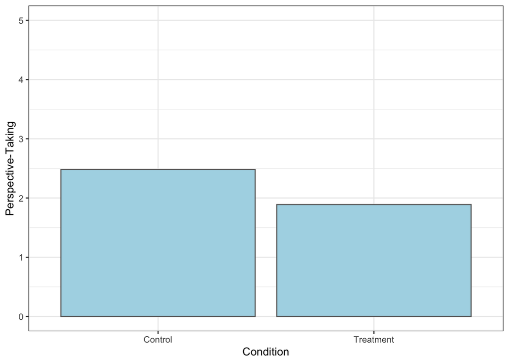

### b. 🟢

*I sometimes tried to understand my coworkers better by imagining how things look from their perspective.*

```
Call:
lm(formula = IRI_PT_2_S2 ~ Condition + wave, data = data)

Residuals:
    Min      1Q  Median      3Q     Max
-1.5846 -0.3948 -0.1454  0.4154  0.8546

Coefficients:
                   Estimate Std. Error t value Pr(>|t|)
(Intercept)          4.2648     0.2316  18.412  < 2e-16 ***
ConditionTreatment   0.4392     0.1529   2.873  0.00561 **
wave                -0.0597     0.1518  -0.393  0.69544
---
Signif. codes:  0 '***' 0.001 '**' 0.01 '*' 0.05 '.' 0.1 ' ' 1

Residual standard error: 0.5856 on 60 degrees of freedom
  (152 observations deleted due to missingness)
Multiple R-squared:  0.1217,    Adjusted R-squared:  0.09246
F-statistic: 4.158 on 2 and 60 DF,  p-value: 0.02036
```

```
No summary function supplied, defaulting to `mean_se()`
```

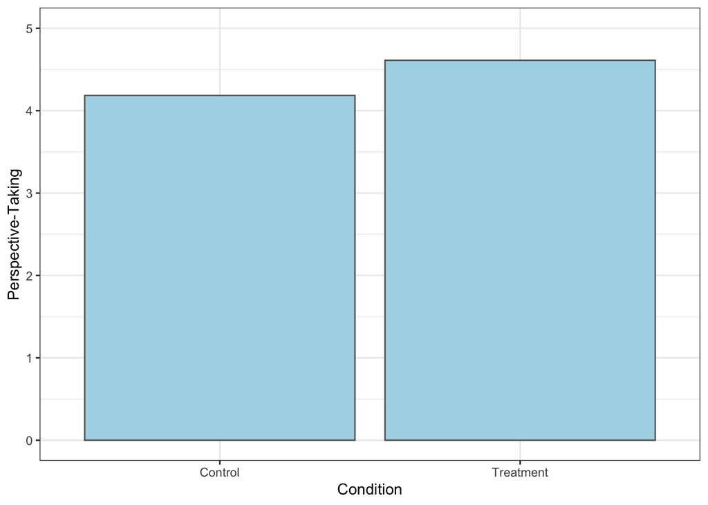

### c. 🔴

*I believed that there are two sides to every question and tried to look at them both.*

```
Call:
lm(formula = IRI_PT_3_S2 ~ Condition + wave, data = data)

Residuals:
    Min      1Q  Median      3Q     Max
-2.1918 -0.3528  0.1515  0.4863  1.1515

Coefficients:
                   Estimate Std. Error t value Pr(>|t|)
(Intercept)          3.5053     0.3043  11.519   <2e-16 ***
ConditionTreatment   0.3219     0.2008   1.603   0.1142
wave                 0.3433     0.1994   1.722   0.0903 .
---
Signif. codes:  0 '***' 0.001 '**' 0.01 '*' 0.05 '.' 0.1 ' ' 1

Residual standard error: 0.7693 on 60 degrees of freedom
  (152 observations deleted due to missingness)
Multiple R-squared:  0.1058,    Adjusted R-squared:  0.07596
F-statistic: 3.548 on 2 and 60 DF,  p-value: 0.03496
```

### d. 🔴

*I tried to look at everybody’s side of a disagreement before I make a decision.*

```
Call:
lm(formula = IRI_PT_4_S2 ~ Condition + wave, data = data)

Residuals:
    Min      1Q  Median      3Q     Max
-1.3396 -0.3396 -0.1343  0.6604  1.0672

Coefficients:
                   Estimate Std. Error t value Pr(>|t|)
(Intercept)          3.7313     0.2611  14.291   <2e-16 ***
ConditionTreatment   0.2052     0.1723   1.191    0.238
wave                 0.2015     0.1711   1.178    0.244
---
Signif. codes:  0 '***' 0.001 '**' 0.01 '*' 0.05 '.' 0.1 ' ' 1

Residual standard error: 0.6601 on 60 degrees of freedom
  (152 observations deleted due to missingness)
Multiple R-squared:  0.0566,    Adjusted R-squared:  0.02516
F-statistic:   1.8 on 2 and 60 DF,  p-value: 0.1741
```

## Scenario

*Your new manager, unlike your previous manager, frequently requests that you get their approval before you make any decision in your work and constantly messages you asking for updates. The new manager seems to forget to CC you on important emails that are related to your job duties, but gets frustrated if they aren’t CC’d on every email that you or your teammates send. When you recently made a minor mistake, the manager brought attention to it and mentioned it to others on your team.*

### Perspective-taking 🟡

```
Call:
lm(formula = IRI_PT1_S2 ~ Condition + wave + manager, data = data)

Residuals:
     Min       1Q   Median       3Q      Max
-2.69461 -0.02415  0.19882  0.31401  1.52836

Coefficients:
                   Estimate Std. Error t value Pr(>|t|)
(Intercept)          3.9003     0.4186   9.318 7.84e-13 ***
ConditionTreatment   0.2230     0.2613   0.853    0.397
wave                -0.2144     0.2632  -0.814    0.419
managerYes           0.1152     0.2613   0.441    0.661
---
Signif. codes:  0 '***' 0.001 '**' 0.01 '*' 0.05 '.' 0.1 ' ' 1

Residual standard error: 0.9365 on 54 degrees of freedom
  (157 observations deleted due to missingness)
Multiple R-squared:  0.02597,   Adjusted R-squared:  -0.02814
F-statistic: 0.4799 on 3 and 54 DF,  p-value: 0.6976
```

```
No summary function supplied, defaulting to `mean_se()`
No summary function supplied, defaulting to `mean_se()`
```

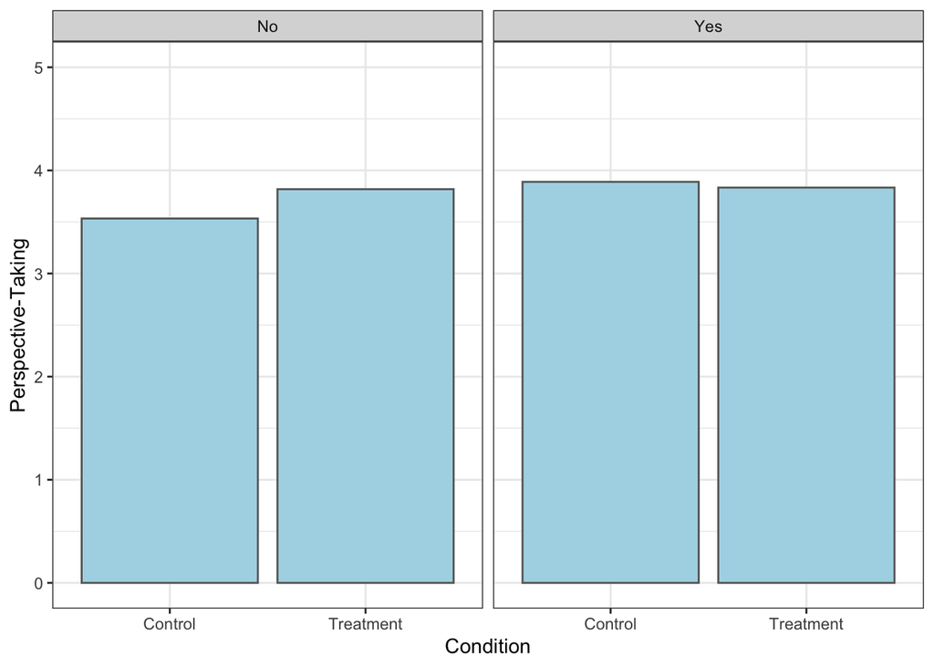

```
Call:
lm(formula = IRI_PT2_S2 ~ Condition + wave + manager, data = data)

Residuals:
    Min      1Q  Median      3Q     Max
-2.7635 -0.1116  0.1189  0.2995  1.6477

Coefficients:
                   Estimate Std. Error t value Pr(>|t|)
(Intercept)          4.0487     0.3746  10.808 4.07e-15 ***
ConditionTreatment   0.4112     0.2339   1.758   0.0844 .
wave                -0.3482     0.2356  -1.478   0.1452
managerYes           0.1806     0.2339   0.772   0.4433
---
Signif. codes:  0 '***' 0.001 '**' 0.01 '*' 0.05 '.' 0.1 ' ' 1

Residual standard error: 0.8381 on 54 degrees of freedom
  (157 observations deleted due to missingness)
Multiple R-squared:  0.08829,   Adjusted R-squared:  0.03764
F-statistic: 1.743 on 3 and 54 DF,  p-value: 0.1691
```

### 360 🟡

```
Call:
lm(formula = X360_S2 ~ Condition + wave + manager, data = data)

Residuals:
     Min       1Q   Median       3Q      Max
-3.07485 -0.47645 -0.07485  0.58514  1.36505

Coefficients:
                   Estimate Std. Error t value Pr(>|t|)
(Intercept)          3.3795     0.4100   8.243    4e-11 ***
ConditionTreatment   0.4399     0.2559   1.719   0.0914 .
wave                 0.1277     0.2578   0.495   0.6224
managerYes           0.4369     0.2559   1.707   0.0935 .
---
Signif. codes:  0 '***' 0.001 '**' 0.01 '*' 0.05 '.' 0.1 ' ' 1

Residual standard error: 0.9172 on 54 degrees of freedom
  (157 observations deleted due to missingness)
Multiple R-squared:  0.109, Adjusted R-squared:  0.05945
F-statistic: 2.201 on 3 and 54 DF,  p-value: 0.09849
```

```
No summary function supplied, defaulting to `mean_se()`
No summary function supplied, defaulting to `mean_se()`
```

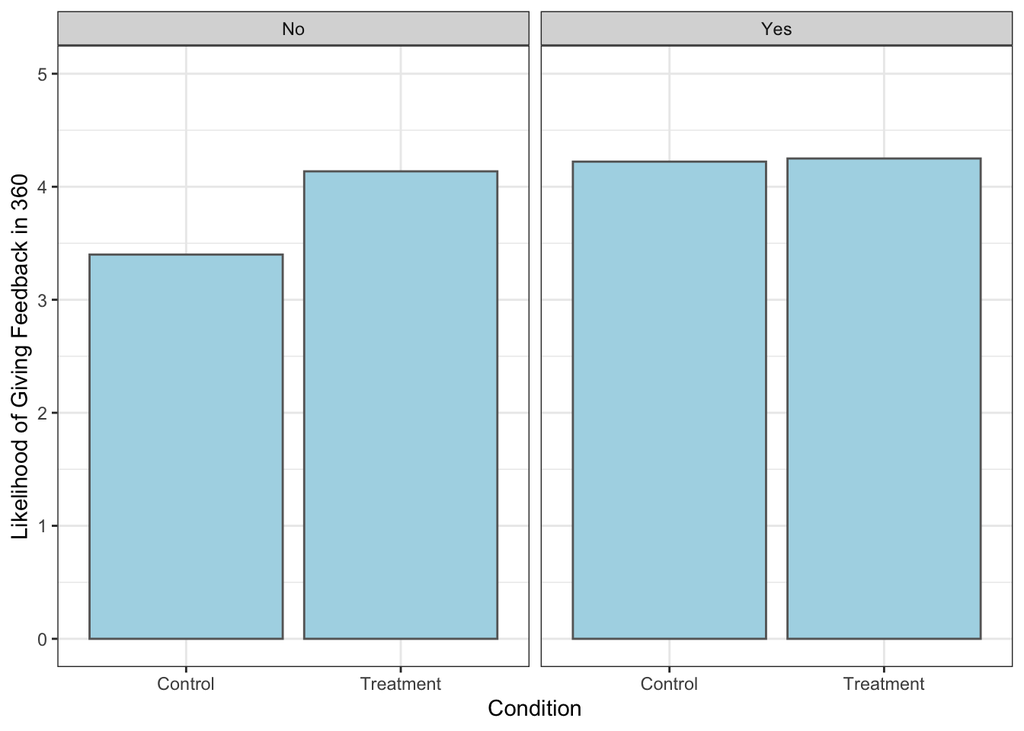

```
Call:
lm(formula = X360Valence_S2 ~ Condition + wave + manager, data = data)

Residuals:
    Min      1Q  Median      3Q     Max
-2.7216 -0.4033  0.1787  0.6256  2.2784

Coefficients:
                   Estimate Std. Error t value Pr(>|t|)
(Intercept)          5.2247     0.4450  11.740   <2e-16 ***
ConditionTreatment   0.3038     0.2778   1.093    0.279
wave                -0.4035     0.2799  -1.442    0.155
managerYes           0.2349     0.2778   0.845    0.402
---
Signif. codes:  0 '***' 0.001 '**' 0.01 '*' 0.05 '.' 0.1 ' ' 1

Residual standard error: 0.9957 on 54 degrees of freedom
  (157 observations deleted due to missingness)
Multiple R-squared:  0.06702,   Adjusted R-squared:  0.01519
F-statistic: 1.293 on 3 and 54 DF,  p-value: 0.2862
```